# Who Moves the Bills? Text Analysis of Congressional Bill Actions

**DATASCI 530 - Assignment 4**  
**Author:** Xueqian Cheng

## Summary of findings

I used regular expressions to pull names, procedures and purposes out of the free-text descriptions of 3,303 actions on legislation in the 116th U.S. Congress (2019-2021).

- **Data.** The actions cover **1,494 distinct bills** (bill type + number). Amendments make up 46% of rows, and House floor actions (31%) are the most common type of action.
- **Senate bills in the House.** There are **116 House floor actions on Senate bills**. **68%** are motions to suspend the rules, a fast-track procedure that needs a two-thirds vote. **16%** are suspensions *as amended*, where the House changed the Senate text.
- **Who moves them.** 53 House members appear. The median member moved a single Senate bill. A few committee chairs moved many, led by Takano (Veterans' Affairs) with 9.
- **Senators on floor amendments.** Among 286 Senate floor amendments, **69% name two senators**: one offers the amendment *for* another. No amendment names more than two. Majority Leader McConnell offered amendments for 57 different senators and Reed for 25, so these pairs reflect floor procedure more than coauthorship.
- **New insight.** Classifying each amendment's stated purpose shows that substantive amendments (substitutes, "to require", "to provide") are usually offered by proxy. Placeholder amendments ("to improve the bill", "to change the enactment date") are offered by McConnell himself, which shows the Majority Leader "filling the amendment tree".

## 0. Setup

**Data.** `bills_actions.csv` (from the course repository, saved locally in `Lecture 09/data_raw/`) holds 3,303 actions taken on bills, resolutions and amendments in the 116th U.S. Congress (2019-2021). Each row is **one action**. The columns used here are:

| Column | Meaning |
| --- | --- |
| `bill_type`, `bill_number` | Together they identify a bill (e.g. `s` + `47` = S. 47) |
| `category` | Kind of legislation (house bill, senate bill, amendment, ...) |
| `main_action` | Type of action (house floor actions, senate amendment proposed, ...) |
| `action` | Free text describing the action - this is what the regular expressions parse |

```python
# Packages
import re
import pandas as pd
import matplotlib.pyplot as plt

# One consistent look for every figure
plt.rcParams.update({"figure.dpi": 110, "font.size": 11, "axes.titlesize": 13,
                     "axes.spines.top": False, "axes.spines.right": False})
MAIN_COLOR = "#2b6cb0"     # blue for main bars
ACCENT_COLOR = "#dd6b20"   # orange to highlight

# Raw data: one row per action
bills_actions = pd.read_csv("../Lecture 09/data_raw/bills_actions.csv")
```

```python
def show_table(df, caption, pct_cols=(), index=False):
    '''Display a DataFrame as a captioned table; pct_cols are shown as percentages.'''
    styler = df.style.set_caption(caption).format(precision=0, thousands=",")
    if pct_cols:
        styler = styler.format("{:.1%}", subset=list(pct_cols))
    if not index:
        styler = styler.hide(axis="index")
    styler = styler.set_table_styles([{"selector": "caption",
                                       "props": "font-weight: bold; font-size: 1.05em; text-align: left;"}])
    display(styler)
```

### 0.1 Quality checks

Before any analysis: size of the data, missing values, and duplicated rows.

```python
print(f"Rows: {bills_actions.shape[0]:,}   Columns: {bills_actions.shape[1]}")
print(f"Congress sessions in the data: {bills_actions['Congress'].unique()}")
print(f"Fully duplicated rows: {bills_actions.duplicated().sum()}")
print("Categories of the duplicated rows:",
      bills_actions.loc[bills_actions.duplicated(keep=False), "category"].value_counts().to_dict())

missing = bills_actions.isna().sum().rename("Missing values").to_frame()
missing.index.name = "Column"
show_table(missing.reset_index(), "Table 0. Missing values per column")
```

```
Rows: 3,303   Columns: 7
Congress sessions in the data: [116]
Fully duplicated rows: 49
Categories of the duplicated rows: {'amendment': 62, 'house bill': 25}
```

Table 0. Missing values per column

| Column | Missing values |
| --- | --- |
| Congress | 0 |
| bill_number | 0 |
| bill_type | 0 |
| action | 0 |
| main_action | 0 |
| category | 0 |
| member_id | 0 |

There are no missing values, and all rows come from the 116th Congress. The 49 fully duplicated rows are kept. They are routine House procedural steps (e.g. *"Ms. Lofgren moved that the committee rise."*) that really do happen several times while a long bill is debated, and the data has no date column to tell them apart. None of them fall in the Senate bill or Senate amendment subsets analyzed in Sections 2-3, and they do not change any count of *distinct* bills.

**Bill identifier.** `bill_number` alone is *not* unique: H.R. 47 and S. 47 are different bills. I therefore build `bill_id = bill_type + bill_number` (e.g. `s47`).

```python
# bill_id: unique identifier of a bill, e.g. "hr1234" or "s47"
bills_actions["bill_id"] = bills_actions["bill_type"] + bills_actions["bill_number"].astype(str)

n_numbers = bills_actions["bill_number"].nunique()
n_bills = bills_actions["bill_id"].nunique()
print(f"Distinct bill_number values:        {n_numbers:,}")
print(f"Distinct bills (bill_type + number): {n_bills:,}")
```

```
Distinct bill_number values:        1,331
Distinct bills (bill_type + number): 1,494
```

## 1. Descriptive statistics

### 1.1 Share of rows by category and by main action

```python
def share_table(column, label):
    '''Count rows per value of `column` and add the share of all rows.'''
    out = (bills_actions[column].value_counts()
           .rename_axis(label).reset_index(name="Actions"))
    out["Share of actions"] = out["Actions"] / out["Actions"].sum()
    out[label] = out[label].str.capitalize()
    return out

category_shares = share_table("category", "Category")
main_action_shares = share_table("main_action", "Main action")

show_table(category_shares, "Table 1. Actions by category", pct_cols=["Share of actions"])
```

Table 1. Actions by category

| Category | Actions | Share of actions |
| --- | --- | --- |
| Amendment | 1,529 | 46.3% |
| House bill | 902 | 27.3% |
| Senate bill | 514 | 15.6% |
| House resolution | 234 | 7.1% |
| Senate resolution | 60 | 1.8% |
| House joint resolution | 22 | 0.7% |
| House concurrent resolution | 20 | 0.6% |
| Senate concurrent resolution | 14 | 0.4% |
| Senate joint resolution | 8 | 0.2% |

```python
show_table(main_action_shares, "Table 2. Actions by main action", pct_cols=["Share of actions"])
```

Table 2. Actions by main action

| Main action | Actions | Share of actions |
| --- | --- | --- |
| House floor actions | 1,020 | 30.9% |
| House amendment offered | 828 | 25.1% |
| Senate committee/subcommittee actions | 434 | 13.1% |
| Other house amendment actions | 397 | 12.0% |
| Senate amendment proposed (on the floor) | 286 | 8.7% |
| House committee/subcommittee actions | 218 | 6.6% |
| Reported to senate | 36 | 1.1% |
| Senate committee report filed after reporting | 33 | 1.0% |
| Other senate amendment actions | 18 | 0.5% |
| Resolving differences -- house actions | 14 | 0.4% |
| Senate floor actions | 13 | 0.4% |
| House discharge petition filed | 3 | 0.1% |
| Resolving differences -- senate actions | 3 | 0.1% |

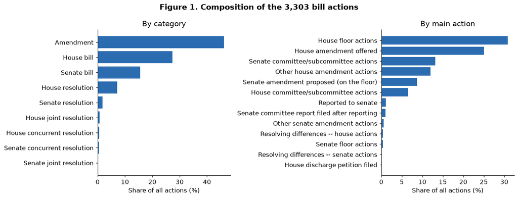

```python
fig, axes = plt.subplots(1, 2, figsize=(13, 5))
for ax, df, label, title in [(axes[0], category_shares, "Category", "By category"),
                             (axes[1], main_action_shares, "Main action", "By main action")]:
    df = df.sort_values("Share of actions")
    ax.barh(df[label], df["Share of actions"] * 100, color=MAIN_COLOR)
    ax.set_xlabel("Share of all actions (%)")
    ax.set_title(title)
fig.suptitle("Figure 1. Composition of the 3,303 bill actions", fontsize=14, fontweight="bold")
fig.tight_layout()
plt.show()
```

Amendments are almost half of all actions (46%), and House bills outnumber Senate bills by almost two to one. On the action side, the House dominates: House floor actions and House amendments together make up more than half of all rows. Floor amendments in the Senate (the subject of Section 3) are 8.7% of the data.

## 2. House floor actions on Senate bills

A Senate bill only becomes law if the House also passes it. This section looks at the House floor actions on Senate bills: `category == "senate bill"` and `main_action == "house floor actions"`.

```python
# house_on_senate: House floor actions taken on Senate bills
house_on_senate = bills_actions.query(
    'category == "senate bill" and main_action == "house floor actions"').copy()

print(f"House floor actions on Senate bills: {len(house_on_senate)}")
print(f"Distinct Senate bills involved:      {house_on_senate['bill_id'].nunique()}")
```

```
House floor actions on Senate bills: 116
Distinct Senate bills involved:      115
```

### 2.1 Suspensions of the rules

"Suspending the rules" is a fast-track procedure in the House: debate is limited to 40 minutes, no amendments can be offered from the floor, and the bill needs a two-thirds majority.

**Coding decisions.**

- An action counts as a *suspension* if its text contains the motion `moved to suspend the rules`. I do not simply search for the word "suspend": one "ORDER OF BUSINESS" entry only *mentions* a future motion to suspend (extending its debate time) and is not itself a motion.
- An action counts as *suspended as amended* if the motion ends with `, as amended`, meaning the House changed the Senate text before passing it. These are a subset of the suspensions.

```python
house_on_senate["suspended"] = house_on_senate["action"].str.contains(r"moved to suspend the rules")
house_on_senate["suspended_as_amended"] = house_on_senate["action"].str.contains(
    r"moved to suspend the rules.*, as amended")

# Quality check: the broad keyword search catches one extra row that is not a motion
broad = house_on_senate["action"].str.contains("suspend", case=False)
print("Rows matching 'suspend' but not the motion:")
for text in house_on_senate.loc[broad & ~house_on_senate["suspended"], "action"]:
    print("   ", text)

n = len(house_on_senate)
suspension_table = pd.DataFrame({
    "Type of action": ["Motion to suspend the rules (any)",
                       "   of which: as amended",
                       "   of which: original Senate text",
                       "Other floor actions (unanimous consent, etc.)"],
    "Actions": [house_on_senate["suspended"].sum(),
                house_on_senate["suspended_as_amended"].sum(),
                (house_on_senate["suspended"] & ~house_on_senate["suspended_as_amended"]).sum(),
                (~house_on_senate["suspended"]).sum()]})
suspension_table["Share of all House floor actions"] = suspension_table["Actions"] / n
show_table(suspension_table, f"Table 3. House floor actions on Senate bills (N = {n})",
           pct_cols=["Share of all House floor actions"])
```

```
Rows matching 'suspend' but not the motion:
    ORDER OF BUSINESS - Mr. Grijalva asked unanimous consent that debate under 1(c) of Rule XV on a motion to suspend the rules relating to S. 47 be extended to 50 minutes. Agreed to without objection.
```

Table 3. House floor actions on Senate bills (N = 116)

| Type of action | Actions | Share of all House floor actions |
| --- | --- | --- |
| Motion to suspend the rules (any) | 79 | 68.1% |
| of which: as amended | 18 | 15.5% |
| of which: original Senate text | 61 | 52.6% |
| Other floor actions (unanimous consent, etc.) | 37 | 31.9% |

About two-thirds of House floor actions on Senate bills are motions to suspend the rules, so most Senate bills that reach the House floor go through the fast track. Only about one in seven actions (18 of 116) passes the bill *as amended*, i.e. with House changes that send the bill back to the Senate. Almost all of the remaining actions are unanimous-consent requests, another fast procedure ("take from the Speaker's table and consider", "discharge from committee and consider").

### 2.2 Who moves Senate bills on the House floor?

Every House floor action starts with the member who made the motion, e.g. *"Ms. Kelly (IL) asked unanimous consent ..."* or *"Ms. Horn, Kendra S. moved to suspend ..."*.

**Regular expression.** `(Mr|Ms|Mrs)\. (.+?)(?= moved| asked)`

- `(Mr|Ms|Mrs)\.` - the title, captured separately;
- `(.+?)` - the name: the shortest run of characters...
- `(?= moved| asked)` - ...up to the verb (a look-ahead, so the verb itself is not captured).

Stopping at the verb, instead of taking a single word, keeps multi-word names intact ("Jackson Lee", "Torres Small (NM)", "Horn, Kendra S."). The state in brackets is kept because the House uses it to tell apart members with the same surname (e.g. Larsen (WA) vs. Larson (CT)).

```python
name_pattern = r"(Mr|Ms|Mrs)\. (.+?)(?= moved| asked)"
house_on_senate[["title", "member"]] = house_on_senate["action"].str.extract(name_pattern)

# Quality check: every action should contain exactly one name
print(f"Actions without an extracted name: {house_on_senate['member'].isna().sum()}")
print(f"Distinct members extracted:        {house_on_senate['member'].nunique()}")
```

```
Actions without an extracted name: 0
Distinct members extracted:        53
```

```python
# member_bills: one row per member, number of distinct Senate bills they moved on the floor
member_bills = (house_on_senate
                .groupby("member")
                .agg(title=("title", "first"),
                     bills=("bill_id", "nunique"),
                     actions=("action", "size"))
                .sort_values(["bills", "member"], ascending=[False, True])
                .reset_index())

# The unique list of names mentioned
unique_members = member_bills["member"].sort_values().tolist()
print(f"{len(unique_members)} unique members:\n")
print(", ".join(unique_members))
```

[output not shown]

```python
top_members = member_bills.head(10).copy()
top_members["member"] = top_members["title"] + ". " + top_members["member"]
top_members = top_members.rename(columns={"member": "Member", "bills": "Senate bills",
                                          "actions": "Floor actions"}).drop(columns="title")
show_table(top_members, "Table 4. The 10 House members who moved the most Senate bills")
```

Table 4. The 10 House members who moved the most Senate bills

| Member | Senate bills | Floor actions |
| --- | --- | --- |
| Mr. Takano | 9 | 9 |
| Mrs. Dingell | 6 | 6 |
| Ms. Haaland | 6 | 6 |
| Ms. Bass | 5 | 5 |
| Mr. Case | 5 | 5 |
| Ms. Kelly (IL) | 5 | 5 |
| Mr. Pallone | 5 | 5 |
| Mr. Cicilline | 4 | 4 |
| Mr. DeFazio | 4 | 4 |
| Mr. Huffman | 4 | 4 |

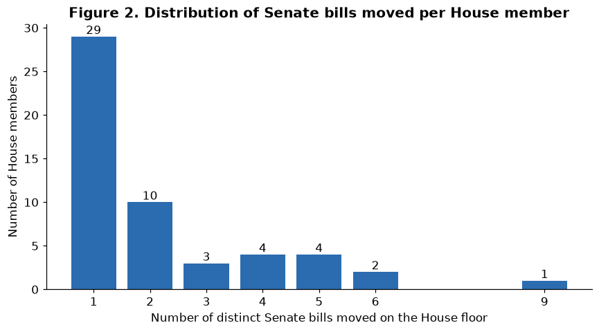

```
count    53.00
mean      2.17
std       1.77
min       1.00
25%       1.00
50%       1.00
75%       3.00
max       9.00
```

```python
# Distribution: how many members moved 1, 2, 3, ... Senate bills
bills_per_member = (member_bills["bills"].value_counts().sort_index()
                    .rename_axis("Senate bills moved").reset_index(name="Members"))
bills_per_member["Share of members"] = bills_per_member["Members"] / bills_per_member["Members"].sum()

fig, ax = plt.subplots(figsize=(8, 4.5))
ax.bar(bills_per_member["Senate bills moved"], bills_per_member["Members"], color=MAIN_COLOR)
for x, y in zip(bills_per_member["Senate bills moved"], bills_per_member["Members"]):
    ax.text(x, y + 0.3, str(y), ha="center")
ax.set_xticks(bills_per_member["Senate bills moved"])
ax.set_xlabel("Number of distinct Senate bills moved on the House floor")
ax.set_ylabel("Number of House members")
ax.set_title("Figure 2. Distribution of Senate bills moved per House member", fontweight="bold")
fig.tight_layout()
plt.show()

print(member_bills["bills"].describe().round(2).to_string())
```

The distribution is strongly right-skewed: the median member moved a single Senate bill, while Mark Takano (chair of Veterans' Affairs) moved nine. Several others at the top are committee chairs, such as Pallone (Energy and Commerce) and DeFazio (Transportation), or members of the committee with jurisdiction over the bill. On the House floor, a member of that committee "manages" a Senate bill, so these counts measure **who manages floor time on behalf of a committee**, not who wrote the bill.

## 3. Senate floor amendments: how many senators per amendment?

The subset here is `main_action == "senate amendment proposed (on the floor)"`. A typical text is

> *S.Amdt.2341 Amendment SA 2341 proposed by **Senator Reed** for **Senator Wyden** to Amendment SA 2301 ...*

When two senators appear, the first (**Senator 1**) is the senator who formally offered the amendment on the floor, and the second (**Senator 2**) is the senator on whose behalf it was offered, usually the real author.

**Unit of observation.** Each row is one amendment attached to a bill, and a bill can receive many amendments (one bill in this subset has 52). Counting senators "per bill" therefore means counting them per bill *action* (per amendment row); combining all amendments of a bill would make "Senator 1" and "Senator 2" meaningless.

**Regular expression.** `Senator ([A-Z][a-zA-Z]+(?: (?:[A-Z][a-z]+|[A-Z]{2}))?)`

- `Senator` - the literal title;
- `[A-Z][a-zA-Z]+` - a capitalized surname (allows internal capitals, as in *McConnell*, *McSally*);
- `(?: ...)?` - optionally a second capitalized word, either another part of the surname (*Van Hollen*, *Cortez Masto*) or a two-letter state that tells apart same-name senators (*Scott FL* vs. *Scott SC*).

```python
# senate_amendments: Senate floor amendment actions
senate_amendments = bills_actions.query(
    'main_action == "senate amendment proposed (on the floor)"').copy()

senator_pattern = r"Senator ([A-Z][a-zA-Z]+(?: (?:[A-Z][a-z]+|[A-Z]{2}))?)"
senate_amendments["senators"] = senate_amendments["action"].str.findall(senator_pattern)

# amendment_senators: the new dataset (one row per amendment action)
amendment_senators = pd.DataFrame({
    "bill_id": senate_amendments["bill_id"],
    "n_senators": senate_amendments["senators"].str.len(),
    "senator_1": senate_amendments["senators"].str[0],
    "senator_2": senate_amendments["senators"].str[1],   # NaN when only one senator
})

# Quality checks
word_count = senate_amendments["action"].str.count(r"\bSenator\b")
print(f"Amendment actions: {len(amendment_senators)} on {amendment_senators['bill_id'].nunique()} distinct bills")
print(f"Rows where #names extracted != #times 'Senator' appears: {(word_count != amendment_senators['n_senators']).sum()}")
print(f"Missing Senator 1: {amendment_senators['senator_1'].isna().sum()}")
print(f"Missing Senator 2 (expected = rows with one senator): "
      f"{amendment_senators['senator_2'].isna().sum()} vs {(amendment_senators['n_senators'] == 1).sum()}")
```

```
Amendment actions: 286 on 131 distinct bills
Rows where #names extracted != #times 'Senator' appears: 0
Missing Senator 1: 0
Missing Senator 2 (expected = rows with one senator): 90 vs 90
```

```python
show_table(amendment_senators.head(8).rename(columns={
               "bill_id": "Bill", "n_senators": "Senators mentioned",
               "senator_1": "Senator 1", "senator_2": "Senator 2"}).fillna("-"),
           "Table 5. First rows of the senators-per-amendment dataset")
```

Table 5. First rows of the senators-per-amendment dataset

| Bill | Senators mentioned | Senator 1 | Senator 2 |
| --- | --- | --- | --- |
| s1029 | 2 | McConnell | Cornyn |
| s1031 | 1 | Hawley | - |
| s1160 | 2 | McConnell | Smith |
| s1253 | 2 | Feinstein | Cornyn |
| s1309 | 2 | McConnell | Cardin |
| s1340 | 2 | Rubio | Menendez |
| s1387 | 2 | Moran | Braun |
| s1434 | 2 | McConnell | Portman |

```python
senators_dist = (amendment_senators["n_senators"].value_counts().sort_index()
                 .rename_axis("Senators mentioned").reset_index(name="Amendments"))
senators_dist["Share"] = senators_dist["Amendments"] / senators_dist["Amendments"].sum()
show_table(senators_dist, "Table 6. Distribution of the number of senators per amendment",
           pct_cols=["Share"])
```

Table 6. Distribution of the number of senators per amendment

| Senators mentioned | Amendments | Share |
| --- | --- | --- |
| 1 | 90 | 31.5% |
| 2 | 196 | 68.5% |

Every amendment mentions either one or two senators; none mention more. About two-thirds are offered **by one senator on behalf of another**, so floor amendments are mostly a collaborative (or procedural) affair rather than a senator acting alone.

### 3.1 With how many different people does each Senator 1 "coauthor"?

For the amendments with two senators, I count the number of **distinct** Senator 2 names for every Senator 1.

```python
pairs = amendment_senators.dropna(subset=["senator_2"])

# coauthors: one row per Senator 1
coauthors = (pairs.groupby("senator_1")
             .agg(partners=("senator_2", "nunique"), amendments=("senator_2", "size"))
             .sort_values(["partners", "amendments"], ascending=False)
             .reset_index())

print(f"Senator 1 names with at least one partner: {len(coauthors)}")
show_table(coauthors.head(10).rename(columns={"senator_1": "Senator 1",
                                     "partners": "Distinct Senator 2 partners",
                                     "amendments": "Amendments offered for others"}),
           "Table 7. Number of different partners (Senator 2) per Senator 1 (top 10; all in Figure 3)")
```

```
Senator 1 names with at least one partner: 21
```

Table 7. Number of different partners (Senator 2) per Senator 1 (top 10; all in Figure 3)

| Senator 1 | Distinct Senator 2 partners | Amendments offered for others |
| --- | --- | --- |
| McConnell | 57 | 112 |
| Reed | 25 | 30 |
| Cornyn | 9 | 9 |
| Cramer | 7 | 7 |
| Murkowski | 6 | 6 |
| Braun | 5 | 5 |
| Moran | 4 | 4 |
| Thune | 3 | 5 |
| Lee | 3 | 3 |
| Fischer | 2 | 2 |

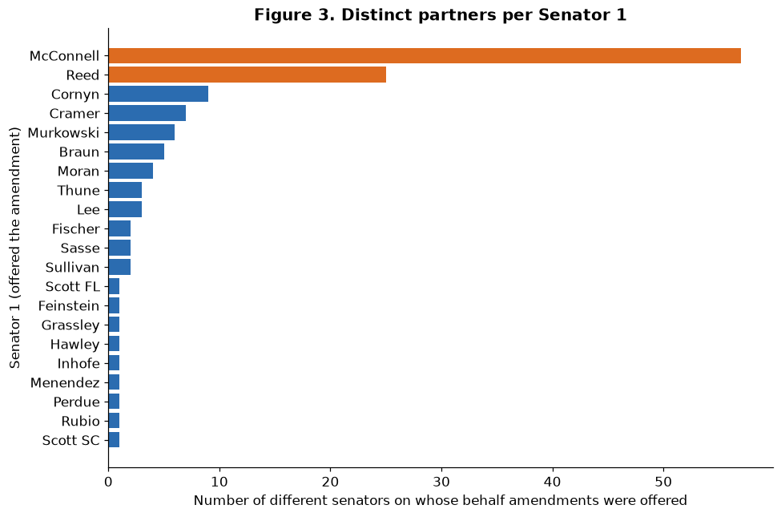

```python
fig, ax = plt.subplots(figsize=(9, 6))
plot_df = coauthors.sort_values("partners")
colors = [ACCENT_COLOR if p >= 10 else MAIN_COLOR for p in plot_df["partners"]]
ax.barh(plot_df["senator_1"], plot_df["partners"], color=colors)
ax.set_xlabel("Number of different senators on whose behalf amendments were offered")
ax.set_ylabel("Senator 1 (offered the amendment)")
ax.set_title("Figure 3. Distinct partners per Senator 1", fontweight="bold")
fig.tight_layout()
plt.show()
```

The result is dominated by two senators. **McConnell** (Majority Leader) offered 112 amendments for 57 different senators, from both parties. **Reed** (top Democrat on Armed Services) offered amendments for 25 colleagues, mostly during the defense authorization debate. Of the 21 senators who ever offered an amendment for someone else, 9 did so for only one colleague.

This shows that "Senator 1 / Senator 2" is mostly **not coauthorship** in the usual sense: party and committee leaders formally offer amendments for colleagues as part of their floor-management role. A real coauthorship network would need the list of cosponsors, which is not in this dataset.

## 5. New insight: what do Senate floor amendments try to do?

**(f)** Besides *who* offers them, the text of each Senate amendment ends with a short statement of its **purpose**, for example *"To require the Secretary of the Army to submit ..."* or *"In the nature of a substitute."* I extract that statement with a regular expression and classify it by its first verb.

**Regular expressions.**

1. `\)\s*(.+)$` - the purpose is everything after the closing bracket of the Congressional Record reference `(consideration: ... )`. Two amendments have no such reference; for them the fallback `Senator [A-Z][\w ]*?\.\s*(.+)$` takes the text after the senator's name.
2. `^To (\w+)` - for purposes starting with "To", the next word is the verb (*require*, *provide*, ...). Exception: the boilerplate texts *"To improve the bill."* and *"To change the enactment date."* say nothing about content. They are grouped as **placeholder** amendments. Purposes that do not start with "To" are procedural ("In the nature of a substitute", "Of a perfecting nature") and are labelled by their own text.

```python
# purpose: text after the Congressional Record reference
senate_amendments["purpose"] = (senate_amendments["action"].str.extract(r"\)\s*(.+)$")[0]
                                 .fillna(senate_amendments["action"].str.extract(r"Senator [A-Z][\w ]*?\.\s*(.+)$")[0])
                                 .str.strip())
print(f"Amendments without an extracted purpose: {senate_amendments['purpose'].isna().sum()}")

def classify_purpose(text):
    '''Return the verb after "To", or a procedural label.'''
    if pd.isna(text):
        return "No purpose stated"
    if text.startswith("To improve the bill") or text.startswith("To change the enactment date"):
        return "Placeholder (\"To improve the bill\", etc.)"
    verb = re.match(r"^To (\w+)", text)
    if verb:
        return "To " + verb.group(1).lower()
    if re.search(r"substitute", text, flags=re.IGNORECASE):
        return "Substitute (replace full text)"
    if re.search(r"perfecting", text, flags=re.IGNORECASE):
        return "Perfecting (technical)"
    return "Other"

senate_amendments["purpose_type"] = senate_amendments["purpose"].apply(classify_purpose)
senate_amendments["n_senators"] = amendment_senators["n_senators"]
```

```
Amendments without an extracted purpose: 0
```

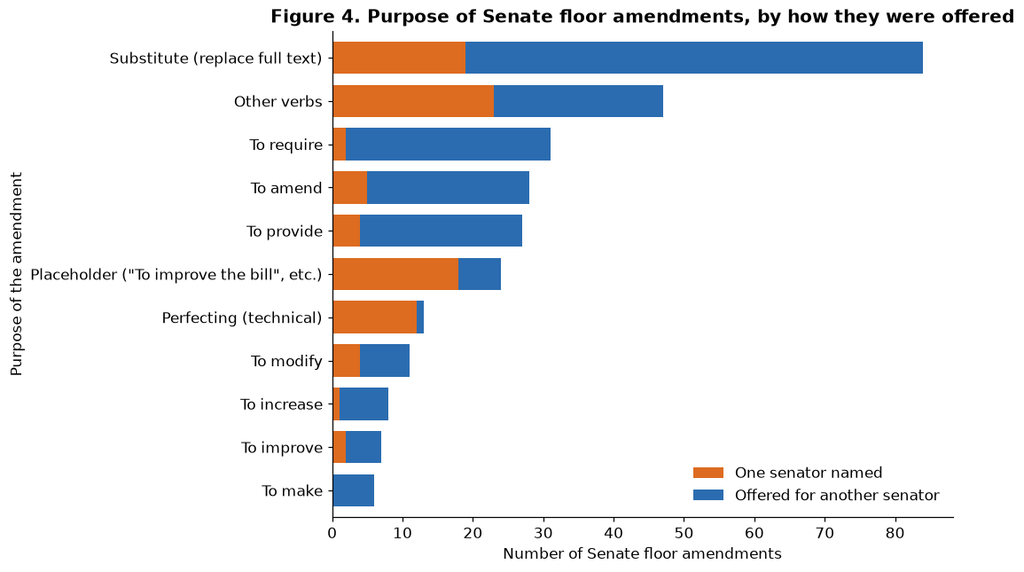

```python
# Keep the 10 most common purposes and group the rest as "Other verbs"
top_purposes = senate_amendments["purpose_type"].value_counts().head(10).index
senate_amendments["purpose_group"] = senate_amendments["purpose_type"].where(
    senate_amendments["purpose_type"].isin(top_purposes), "Other verbs")

purpose_by_proxy = (pd.crosstab(senate_amendments["purpose_group"],
                                senate_amendments["n_senators"].map({1: "One senator named",
                                                                     2: "Offered for another senator"}))
                    .assign(Total=lambda d: d.sum(axis=1))
                    .sort_values("Total"))

fig, ax = plt.subplots(figsize=(10, 6))
purpose_by_proxy[["One senator named", "Offered for another senator"]].plot(
    kind="barh", stacked=True, ax=ax, color=[ACCENT_COLOR, MAIN_COLOR], width=0.75)
ax.set_xlabel("Number of Senate floor amendments")
ax.set_ylabel("Purpose of the amendment")
ax.set_title("Figure 4. Purpose of Senate floor amendments, by how they were offered", fontweight="bold")
ax.legend(title="", loc="lower right", frameon=False)
fig.tight_layout()
plt.show()
```

```python
purpose_table = purpose_by_proxy.sort_values("Total", ascending=False).reset_index()
purpose_table["Share offered on behalf"] = (purpose_table["Offered for another senator"]
                                            / purpose_table["Total"])
purpose_table = purpose_table.rename(columns={"purpose_group": "Purpose"})
purpose_table.columns.name = None
show_table(purpose_table, "Table 8. Purpose of Senate floor amendments",
           pct_cols=["Share offered on behalf"])
```

Table 8. Purpose of Senate floor amendments

| Purpose | Offered for another senator | One senator named | Total | Share offered on behalf |
| --- | --- | --- | --- | --- |
| Substitute (replace full text) | 65 | 19 | 84 | 77.4% |
| Other verbs | 24 | 23 | 47 | 51.1% |
| To require | 29 | 2 | 31 | 93.5% |
| To amend | 23 | 5 | 28 | 82.1% |
| To provide | 23 | 4 | 27 | 85.2% |
| Placeholder ("To improve the bill", etc.) | 6 | 18 | 24 | 25.0% |
| Perfecting (technical) | 1 | 12 | 13 | 7.7% |
| To modify | 7 | 4 | 11 | 63.6% |
| To increase | 7 | 1 | 8 | 87.5% |
| To improve | 5 | 2 | 7 | 71.4% |
| To make | 6 | 0 | 6 | 100.0% |

**(g) What do we learn?**

- **Most floor amendments make real policy changes.** The largest group is amendments "in the nature of a substitute", which replace the whole text of a bill, typically with a negotiated version. Next come amendments that *require* an agency to act, *amend* existing law, or *provide* funds.
- **Substantive amendments travel by proxy.** Over 80% of "To require", "To amend" and "To provide" amendments, and about 80% of substitutes, are offered by one senator on behalf of another. This matches the leaders' role found in Section 3: individual senators write the content and leaders bring it to the floor.
- **Procedural amendments are offered by the leader himself.** The placeholder amendments ("To improve the bill", "To change the enactment date") and the "perfecting" amendments are mostly offered by McConnell alone, with no second senator: 29 of these 37 amendments. This pattern is known as **"filling the amendment tree"**: the Majority Leader takes up every available amendment slot with placeholder text so that no other senator can offer amendments.
- Together with Section 3, this shows that the same "Senator 1" can play two very different roles: a broker for colleagues' substantive amendments, and a gatekeeper who uses placeholder amendments to control the floor.